# Model composition

Large models are easier to build, test and maintain when assembled from smaller, independently validated **submodels** — for example a metabolic core plus a separate regulatory layer.

`mxlpy.compose` merges two or more `Model` objects into a single new model. Components are identified **by name** across the whole namespace (variables, parameters, derived quantities, reactions, readouts, surrogates and data), and the input models are never mutated.

```
from mxlpy import compose

full_model = compose(submodel_a, submodel_b)
```

```python
from __future__ import annotations

import matplotlib.pyplot as plt

from mxlpy import Model, Simulator, compose, fns, plot
```

## Merging disjoint submodels

If two models share no names, `compose` simply returns a new model containing the union of all their components.

```python
def production() -> Model:
    return (
        Model()
        .add_parameter("k_in", 1.0)
        .add_variable("x", 1.0)
        .add_reaction("v_in", fns.constant, args=["k_in"], stoichiometry={"x": 1})
    )


def independent() -> Model:
    return (
        Model()
        .add_parameter("k2", 2.0)
        .add_variable("y", 3.0)
        .add_reaction("v2", fns.constant, args=["k2"], stoichiometry={"y": 1})
    )


merged = compose(production(), independent())
sorted(merged.ids)
```

```
['k2', 'k_in', 'v2', 'v_in', 'x', 'y']
```

## Name conflicts

By default any name defined in more than one model is treated as a conflict and raises a `ValueError`. This protects you from silently merging two unrelated components that happen to share a name.

```python
def consumption() -> Model:
    return (
        Model()
        .add_parameter("k_out", 1.0)
        .add_variable("x", 1.0)  # same name as in `production`
        .add_reaction(
            "v_out", fns.proportional, args=["k_out", "x"], stoichiometry={"x": -1}
        )
    )


try:
    compose(production(), consumption())
except ValueError as e:
    print(e)
```

```
Cannot compose models: duplicate names ['x']. Rename the conflicting components in one of the models, or pass raise_on_conflict=False to let the later model override them.
```

## Sharing components on purpose

To deliberately connect submodels through a shared component — here the species `x`, produced by one submodel and consumed by the other — pass `raise_on_conflict=False`. A warning is emitted for each overridden name and the component from the **later** model wins.

```python
import warnings

with warnings.catch_warnings():
    warnings.simplefilter("ignore")
    model = compose(production(), consumption(), raise_on_conflict=False)

variables, _ = Simulator(model).simulate(10).get_result().unwrap_or_err()

fig, ax = plot.lines(variables)
ax.set(xlabel="time / a.u.", ylabel="concentration / a.u.")
plt.show()
```

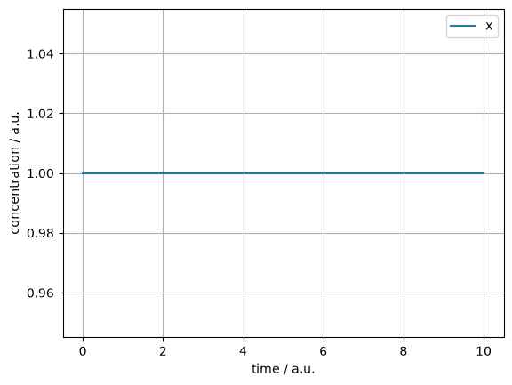

`compose` accepts any number of models (`compose(a, b, c, ...)`), folding them left-to-right, so you can stack several modules in a single call.